# Final Exam

Tim Boudreau

March 16 2016

```r
library(nycflights13)
library(RSQLite)
library(dplyr)
library(ggplot2)
library(class)
```

## Use the NYC Flight data from 2013:

I split the 2013 NYC Flight Data into five data frames, one for each of the relevant categoried - flights, weather, airlines, airports and planes.

I then created data frames for the following: weather data and flight delays and cancelations, airport and flight delays and cancelations, plane characteristics and flight delays and cancelations.

# Data Analysis:

The next section is where I analyze our NYC Flight Data from 2013. Included are figures and statistical significance levels, while regression out put and code is hidden, for cleanliness.

## Delay & Cancelation

First off, we should note that hourly delay has a significant effect, at the 99% confidence level, on the total number of canceled flights per hour.

## Weather

No variable has a statistically significant effect on normalized hourly canceled flights.

Here, temperature, humidity, pressure and visibility have 99% confident, statistically significant effects on delay time. Wind direction, though, is statistically significant at the 90% level.

Temperature, pressure and visibility have a significant effect on the amount of canceled hourly flights, at confidence levels of 99%, 95% and 95% respectively. Wind direction is also significant, though only ata 90% confidence level and when we include other non-significant variables.

As seen in the figure below, a higher temperature leads to more and longer delays. The larger, lighter-colored points are cancelations, which also appear more frequently with higher temperatures.

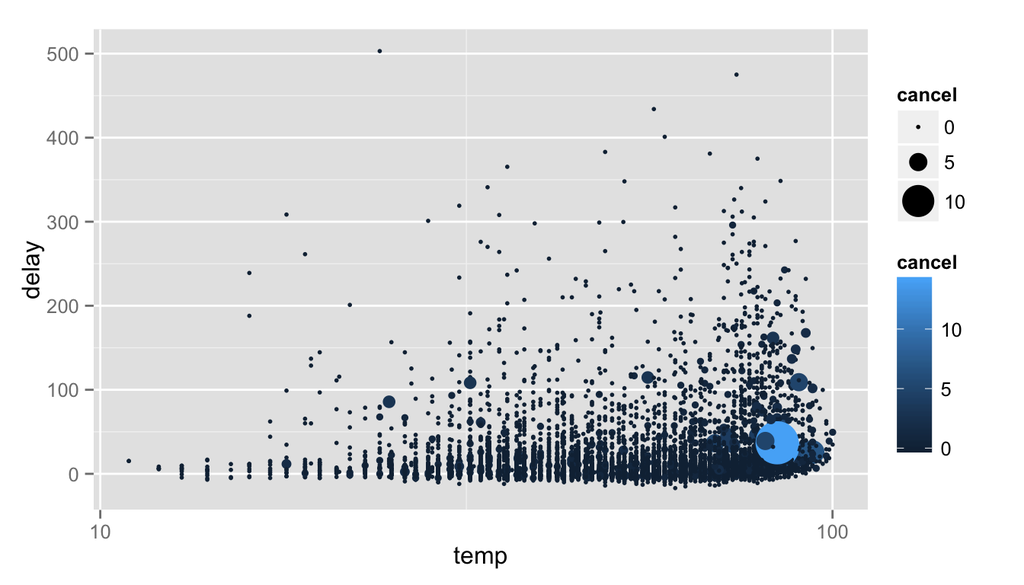

## Time

Out of the time variables, month, hour and minute are statistically significant at the 99% confidence level. Day isn’t statistically significant.

The variables that significantly impact number of flights canceled are hour, at the 99% level, and minutes, at the 95% level.

This graph shows the length of delays relative to the hour of the day the delay occurs. Between midnight and 5 A.M. EST, there are no short delays and, between 1 A.M. and 5 A.M., there are very few longer delays as well. The amount of short delays begins to decrease around 8 P.M., while the amount of long delays begins to increase around 5 A.M.

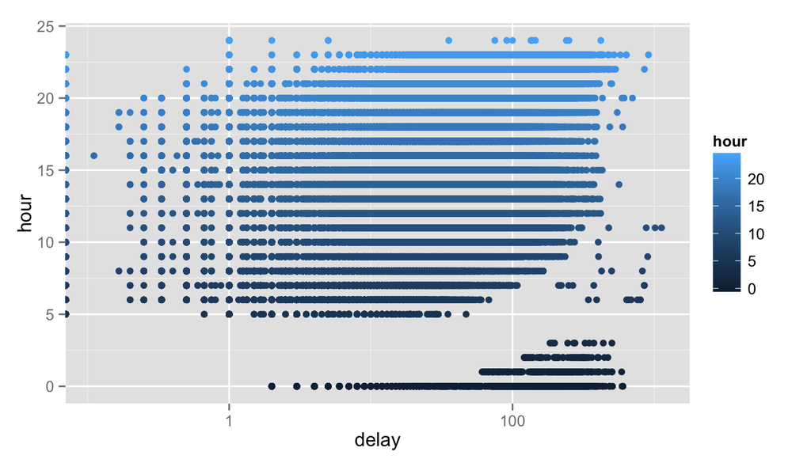

Delay length by time of day, where midnight is both hour 0 and hour 24.

## Airport

Only 25 of the airport destinations significantly effect the delay length.

While 30 airports significantly affected the cancelation of flights:

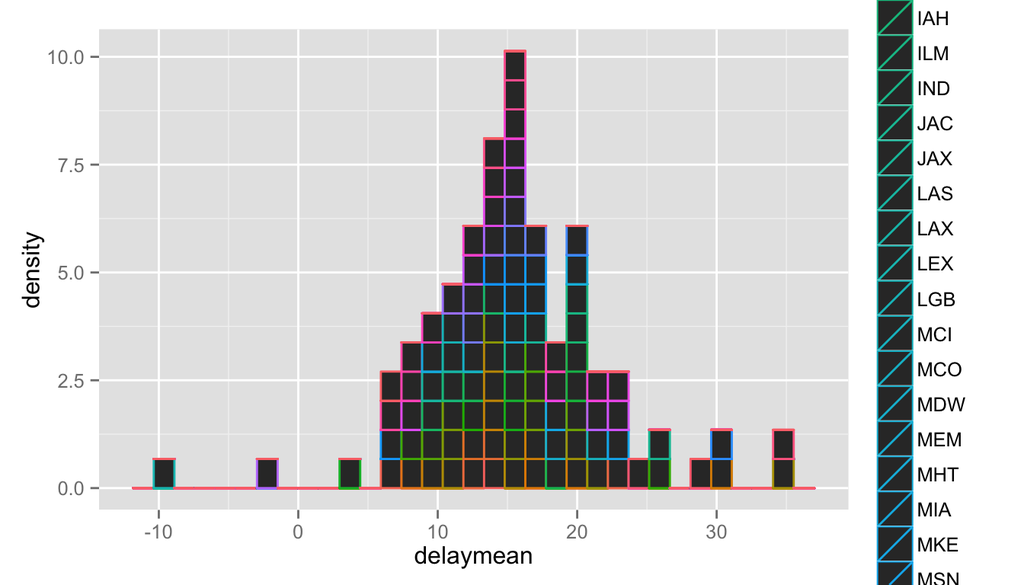

A histogram mapping the frequency of mean densities, by airport. The airports are indicated by color, but the legend was much too large (101 airports!) to include.

## Airplane

None of the engine types are significant by themselves, but various models and plane types (also seen as tail numbers) have a significant effect on delay:

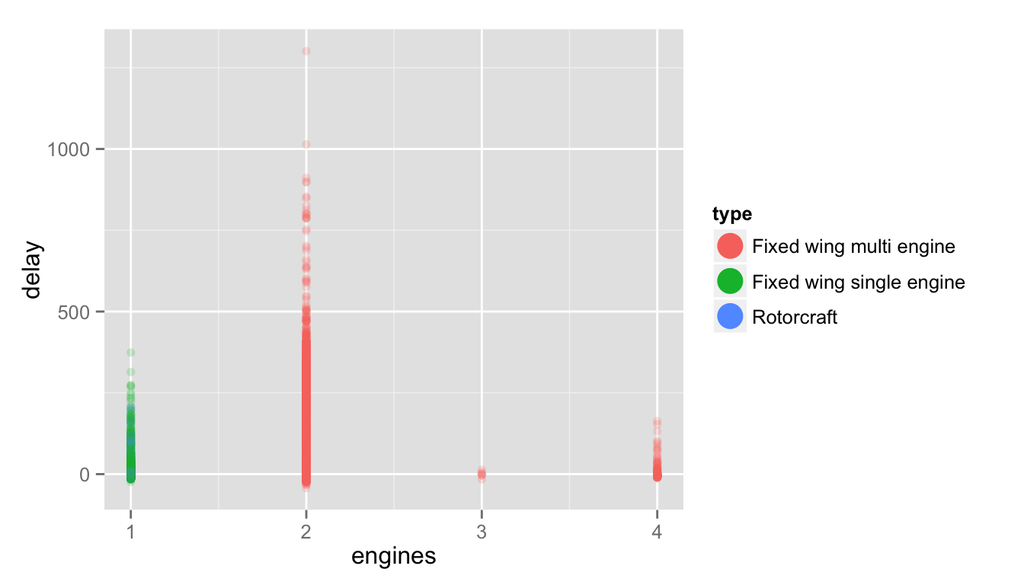

Number of engines on the airplane mapped against the length of delays (and the amount of delays) per amount of engines. The color indicates the type of plane.